# A practical example showing how to retrieve a dataset from the EcoSIS spectral database and plot the results

Shawn P. Serbin

### Overview

This is an [R Markdown](http://rmarkdown.rstudio.com) Notebook to illustrate how to retrieve datasets from the EcoSIS spectral library (https://ecosis.org/). When you click the **Knit** button in Rstudio a document will be generated that includes both content as well as the output of any embedded R code chunks within the document.

### Installation

```r
list.of.packages <- c("readr","httr","dplyr","reshape2","ggplot2")
# check for dependencies and install if needed
new.packages <- list.of.packages[!(list.of.packages %in% installed.packages()[,"Package"])]
if(length(new.packages)) install.packages(new.packages)
```

##### Load libraries

```r
# load libraries needed for script
library(readr)
library(dplyr)
library(reshape2)
library(ggplot2)
```

##### Prepare helpers

```r
# define function to grab PLSR model from GitHub
#devtools::source_gist("gist.github.com/christophergandrud/4466237")
source_GitHubData <-function(url, sep = ",", header = TRUE) {
  require(httr)
  request <- GET(url)
  stop_for_status(request)
  handle <- textConnection(content(request, as = 'text'))
  on.exit(close(handle))
  read.table(handle, sep = sep, header = header)
}

# not in
`%notin%` <- Negate(`%in%`)
```

```r
print(paste0("Output temporary directory: ",outdir))
```

[1] “Output temporary directory: /var/folders/xp/h3k9vf3n2jx181ts786_yjrn9c2gjq/T//RtmpgCgCNZ”

```r
setwd(outdir) # set working directory
getwd()  # check wd
```

[1] “/private/var/folders/xp/h3k9vf3n2jx181ts786_yjrn9c2gjq/T/RtmpgCgCNZ”

### Grab data from EcoSIS

##### URL: https://ecosis.org/package/ngee-arctic-2016-leaf-spectral-reflectance-kougarok-road-seward-peninsula-alaska-2016

```r
print("**** Downloading Ecosis data ****")
```

[1] “**** Downloading Ecosis data ****”

```r
ecosis_id <- "960dbb0c-144e-4563-8117-9e23d14f4aa9"  # NGEE-Arctic dataset
ecosis_file <- sprintf(
  "https://ecosis.org/api/package/%s/export?metadata=true",
  ecosis_id
)
message("Downloading data...")
dat_raw <- read_csv(ecosis_file)
message("Download complete!")
names(dat_raw)[1:40]
```

[1] “BNL_Barcode” “CN_Ratio” “C_area_g_m2” “Cmass_g_g” “Common Name”  
[6] “Foreoptic Specifications” “Instrument Model” “LMA_g_m2” “Latin Genus” “Latin Species”  
[11] “Latitude” “Longitude” “Measurement Quantity” “N_area_g_m2” “Nmass_g_g”  
[16] “Overlap_Handling” “Overlap_Matching_Type” “Overlap_Removal” “Processing Interpolated” “Processing Resampled”  
[21] “Reflectance_Type” “Sample Collection Date” “Sample_ID” “Site” “Spectra_Name”  
[26] “Spectra_Type” “Spectra_Units” “Spectral_Resolution” “USDA Symbol” “White_Reference_Standard” [31] “350” “351” “352” “353” “354”  
[36] “355” “356” “357” “358” “359”

```r
head(dat_raw)
```

| BNL_Barcode | CN_Ratio | C_area_g_m2 | Cmass_g_g | Common Name | Foreoptic Specifications | Instrument Model | LMA_g_m2 | Latin Genus | Latin Species | Latitude | Longitude | Measurement Quantity | N_area_g_m2 | Nmass_g_g | Overlap_Handling | Overlap_Matching_Type | Overlap_Removal | Processing Interpolated | Processing Resampled | Reflectance_Type | Sample Collection Date | Sample_ID | Site | Spectra_Name | Spectra_Type | Spectra_Units | Spectral_Resolution | USDA Symbol | White_Reference_Standard | … |
| --- | --- | --- | --- | --- | --- | --- | --- | --- | --- | --- | --- | --- | --- | --- | --- | --- | --- | --- | --- | --- | --- | --- | --- | --- | --- | --- | --- | --- | --- | --- |
| BNL2181 | 19.340 | 48.069 | 47.77 | Siberian alder | Fiber_1_LC_RP_Pro | SVC_HR-1024i | 100.63 | Alnus | viridis ssp. fruticosa | 65.16536 | -164.8211 | Radiance | 2.485 | 2.47 | Removed | Radiance | Post_processing | Linear | Linear | Absolute | 20160726 | 2181 | Kougarok | BNL2181 | Leaf | Percent_Reflectance_0_100 | 1nm | ALVIF | 99AA10-0614-0827 SRS-99-020 | … |
| BNL2194 | 21.697 | 43.861 | 50.77 | tealeaf willow | Fiber_1_LC_RP_Pro | SVC_HR-1024i | 86.39 | Salix | pulchra | 65.16525 | -164.8214 | Radiance | 2.022 | 2.34 | Removed | Radiance | Post_processing | Linear | Linear | Absolute | 20160726 | 2194 | Kougarok | BNL2194 | Leaf | Percent_Reflectance_0_100 | 1nm | SAPU15 | 99AA10-0614-0827 SRS-99-020 | … |
| BNL2195 | 31.563 | 48.314 | 50.50 | tealeaf willow | Fiber_1_LC_RP_Pro | SVC_HR-1024i | 95.67 | Salix | pulchra | 65.16518 | -164.8218 | Radiance | 1.531 | 1.60 | Removed | Radiance | Post_processing | Linear | Linear | Absolute | 20160726 | 2195 | Kougarok | BNL2195 | Leaf | Percent_Reflectance_0_100 | 1nm | SAPU15 | 99AA10-0614-0827 SRS-99-020 | … |
| BNL2196 | 27.954 | 49.486 | 48.36 | Siberian alder | Fiber_1_LC_RP_Pro | SVC_HR-1024i | 102.33 | Alnus | viridis ssp. fruticosa | 65.16520 | -164.8219 | Radiance | 1.770 | 1.73 | Removed | Radiance | Post_processing | Linear | Linear | Absolute | 20160726 | 2196 | Kougarok | BNL2196 | Leaf | Percent_Reflectance_0_100 | 1nm | ALVIF | 99AA10-0614-0827 SRS-99-020 | … |
| BNL2197 | 25.144 | 44.628 | 49.03 | tealeaf willow | Fiber_1_LC_RP_Pro | SVC_HR-1024i | 91.02 | Salix | pulchra | 65.16519 | -164.8218 | Radiance | 1.775 | 1.95 | Removed | Radiance | Post_processing | Linear | Linear | Absolute | 20160726 | 2197 | Kougarok | BNL2197 | Leaf | Percent_Reflectance_0_100 | 1nm | SAPU15 | 99AA10-0614-0827 SRS-99-020 | … |
| BNL2198 | 17.458 | 51.820 | 47.31 | tealeaf willow | Fiber_1_LC_RP_Pro | SVC_HR-1024i | 109.53 | Salix | pulchra | 65.16518 | -164.8218 | Radiance | 2.968 | 2.71 | Removed | Radiance | Post_processing | Linear | Linear | Absolute | 20160726 | 2198 | Kougarok | BNL2198 | Leaf | Percent_Reflectance_0_100 | 1nm | SAPU15 | 99AA10-0614-0827 SRS-99-020 | … |

### Prepare spectra data

```r
Start.wave <- 500
End.wave <- 2400
wv <- seq(Start.wave,End.wave,1)
spectra <- data.frame(dat_raw[,names(dat_raw) %in% wv])
names(spectra) <- c(paste0("Wave_",wv))
head(spectra)[,1:5]
```

|  | Wave_500 | Wave_501 | Wave_502 | Wave_503 | Wave_504 |
| --- | --- | --- | --- | --- | --- |
| 1 | 2.687619 | 2.705000 | 2.699524 | 2.709048 | 2.716429 |
| 2 | 2.174524 | 2.231667 | 2.283810 | 2.340952 | 2.380952 |
| 3 | 2.159762 | 2.231667 | 2.322857 | 2.432381 | 2.516190 |
| 4 | 3.229524 | 3.258333 | 3.285000 | 3.335000 | 3.342143 |
| 5 | 2.364286 | 2.380000 | 2.413571 | 2.458810 | 2.544762 |
| 6 | 2.226429 | 2.228333 | 2.255238 | 2.283810 | 2.310238 |

```r
sample_info <- dat_raw[,names(dat_raw) %notin% seq(350,2500,1)]
head(sample_info)
```

| BNL_Barcode | CN_Ratio | C_area_g_m2 | Cmass_g_g | Common Name | Foreoptic Specifications | Instrument Model | LMA_g_m2 | Latin Genus | Latin Species | Latitude | Longitude | Measurement Quantity | N_area_g_m2 | Nmass_g_g | Overlap_Handling | Overlap_Matching_Type | Overlap_Removal | Processing Interpolated | Processing Resampled | Reflectance_Type | Sample Collection Date | Sample_ID | Site | Spectra_Name | Spectra_Type | Spectra_Units | Spectral_Resolution | USDA Symbol | White_Reference_Standard |
| --- | --- | --- | --- | --- | --- | --- | --- | --- | --- | --- | --- | --- | --- | --- | --- | --- | --- | --- | --- | --- | --- | --- | --- | --- | --- | --- | --- | --- | --- |
| BNL2181 | 19.340 | 48.069 | 47.77 | Siberian alder | Fiber_1_LC_RP_Pro | SVC_HR-1024i | 100.63 | Alnus | viridis ssp. fruticosa | 65.16536 | -164.8211 | Radiance | 2.485 | 2.47 | Removed | Radiance | Post_processing | Linear | Linear | Absolute | 20160726 | 2181 | Kougarok | BNL2181 | Leaf | Percent_Reflectance_0_100 | 1nm | ALVIF | 99AA10-0614-0827 SRS-99-020 |
| BNL2194 | 21.697 | 43.861 | 50.77 | tealeaf willow | Fiber_1_LC_RP_Pro | SVC_HR-1024i | 86.39 | Salix | pulchra | 65.16525 | -164.8214 | Radiance | 2.022 | 2.34 | Removed | Radiance | Post_processing | Linear | Linear | Absolute | 20160726 | 2194 | Kougarok | BNL2194 | Leaf | Percent_Reflectance_0_100 | 1nm | SAPU15 | 99AA10-0614-0827 SRS-99-020 |
| BNL2195 | 31.563 | 48.314 | 50.50 | tealeaf willow | Fiber_1_LC_RP_Pro | SVC_HR-1024i | 95.67 | Salix | pulchra | 65.16518 | -164.8218 | Radiance | 1.531 | 1.60 | Removed | Radiance | Post_processing | Linear | Linear | Absolute | 20160726 | 2195 | Kougarok | BNL2195 | Leaf | Percent_Reflectance_0_100 | 1nm | SAPU15 | 99AA10-0614-0827 SRS-99-020 |
| BNL2196 | 27.954 | 49.486 | 48.36 | Siberian alder | Fiber_1_LC_RP_Pro | SVC_HR-1024i | 102.33 | Alnus | viridis ssp. fruticosa | 65.16520 | -164.8219 | Radiance | 1.770 | 1.73 | Removed | Radiance | Post_processing | Linear | Linear | Absolute | 20160726 | 2196 | Kougarok | BNL2196 | Leaf | Percent_Reflectance_0_100 | 1nm | ALVIF | 99AA10-0614-0827 SRS-99-020 |
| BNL2197 | 25.144 | 44.628 | 49.03 | tealeaf willow | Fiber_1_LC_RP_Pro | SVC_HR-1024i | 91.02 | Salix | pulchra | 65.16519 | -164.8218 | Radiance | 1.775 | 1.95 | Removed | Radiance | Post_processing | Linear | Linear | Absolute | 20160726 | 2197 | Kougarok | BNL2197 | Leaf | Percent_Reflectance_0_100 | 1nm | SAPU15 | 99AA10-0614-0827 SRS-99-020 |
| BNL2198 | 17.458 | 51.820 | 47.31 | tealeaf willow | Fiber_1_LC_RP_Pro | SVC_HR-1024i | 109.53 | Salix | pulchra | 65.16518 | -164.8218 | Radiance | 2.968 | 2.71 | Removed | Radiance | Post_processing | Linear | Linear | Absolute | 20160726 | 2198 | Kougarok | BNL2198 | Leaf | Percent_Reflectance_0_100 | 1nm | SAPU15 | 99AA10-0614-0827 SRS-99-020 |

```r
cexaxis <- 1.5
cexlab <- 1.8
ylim <- 65
ylim2 <- 65

# calculate some stats
mean_spec <- colMeans(spectra[,which(names(spectra) %in% paste0("Wave_",wv))])
spectra_quantiles <- apply(spectra[,which(names(spectra) %in% paste0("Wave_",wv))],
                           2,quantile,na.rm=T,probs=c(0,0.025,0.05,0.5,0.95,0.975,1))

print("**** Plotting Ecosis specrtal data. Writing to scratch space ****")
```

[1] “**** Plotting Ecosis specrtal data. Writing to scratch space ****”

```r
par(mfrow=c(1,1), mar=c(4.5,5.7,0.3,0.4), oma=c(0.3,0.9,0.3,0.1)) # B, L, T, R
plot(wv,mean_spec,ylim=c(0,ylim),cex=0.00001, col="white",xlab="Wavelength (nm)",
     ylab="Reflectance (%)",cex.axis=cexaxis, cex.lab=cexlab)
polygon(c(wv ,rev(wv)),c(spectra_quantiles[7,], rev(spectra_quantiles[3,])),
        col="#99CC99",border=NA)
```

```r
lines(wv,mean_spec,lwd=3, lty=1, col="black")
lines(wv,spectra_quantiles[1,]*100,lwd=1.85, lty=3, col="grey40")
```

```r
lines(wv,spectra_quantiles[7,]*100,lwd=1.85, lty=3, col="grey40")
legend("topright",legend=c("Mean reflectance","Min/Max", "95% CI"),lty=c(1,3,1),
       lwd=c(3,3,15),col=c("black","grey40","#99CC99"),bty="n", cex=1.7)
```

```r
# save to scratch space
png(file=file.path(outdir,'NGEE-Arctic_2016_Kougarok_leaf_spectra_summary_plot.png'),height=3000,
    width=3900, res=340)
par(mfrow=c(1,1), mar=c(4.5,5.7,0.3,0.4), oma=c(0.3,0.9,0.3,0.1)) # B, L, T, R
plot(wv,mean_spec,ylim=c(0,ylim),cex=0.00001, col="white",xlab="Wavelength (nm)",
     ylab="Reflectance (%)",cex.axis=cexaxis, cex.lab=cexlab)
```

```r
polygon(c(wv ,rev(wv)),c(spectra_quantiles[7,], rev(spectra_quantiles[3,])),
        col="#99CC99",border=NA)
lines(wv,mean_spec,lwd=3, lty=1, col="black")
lines(wv,spectra_quantiles[1,]*100,lwd=1.85, lty=3, col="grey40")
lines(wv,spectra_quantiles[7,]*100,lwd=1.85, lty=3, col="grey40")
legend("topright",legend=c("Mean reflectance","Min/Max", "95% CI"),lty=c(1,3,1),
       lwd=c(3,3,15),col=c("black","grey40","#99CC99"),bty="n", cex=1.7)
box(lwd=2.2)
dev.off()
```

quartz_off_screen 2

[figure not shown]

### Plot associated leaf functional trait data

```r
print("**** Plotting Ecosis trait data. Writing to scratch space ****")
```

[1] “**** Plotting Ecosis trait data. Writing to scratch space ****”

```r
# Organize leaf trait data
names(sample_info)
```

[1] “BNL_Barcode” “CN_Ratio” “C_area_g_m2” “Cmass_g_g” “Common Name”  
[6] “Foreoptic Specifications” “Instrument Model” “LMA_g_m2” “Latin Genus” “Latin Species”  
[11] “Latitude” “Longitude” “Measurement Quantity” “N_area_g_m2” “Nmass_g_g”  
[16] “Overlap_Handling” “Overlap_Matching_Type” “Overlap_Removal” “Processing Interpolated” “Processing Resampled”  
[21] “Reflectance_Type” “Sample Collection Date” “Sample_ID” “Site” “Spectra_Name”  
[26] “Spectra_Type” “Spectra_Units” “Spectral_Resolution” “USDA Symbol” “White_Reference_Standard”

```r
trait_data <- sample_info %>%
  select(Site,Sample_ID,USDA_Species_Code=`USDA Symbol`,Common_Name=`Common Name`,LMA_gDW_m2=LMA_g_m2,
         Nmass_g_g,N_area_g_m2,Cmass_g_g,C_area_g_m2,CN_Ratio)
head(trait_data)
```

| Site | Sample_ID | USDA_Species_Code | Common_Name | LMA_gDW_m2 | Nmass_g_g | N_area_g_m2 | Cmass_g_g | C_area_g_m2 | CN_Ratio |
| --- | --- | --- | --- | --- | --- | --- | --- | --- | --- |
| Kougarok | 2181 | ALVIF | Siberian alder | 100.63 | 2.47 | 2.485 | 47.77 | 48.069 | 19.340 |
| Kougarok | 2194 | SAPU15 | tealeaf willow | 86.39 | 2.34 | 2.022 | 50.77 | 43.861 | 21.697 |
| Kougarok | 2195 | SAPU15 | tealeaf willow | 95.67 | 1.60 | 1.531 | 50.50 | 48.314 | 31.563 |
| Kougarok | 2196 | ALVIF | Siberian alder | 102.33 | 1.73 | 1.770 | 48.36 | 49.486 | 27.954 |
| Kougarok | 2197 | SAPU15 | tealeaf willow | 91.02 | 1.95 | 1.775 | 49.03 | 44.628 | 25.144 |
| Kougarok | 2198 | SAPU15 | tealeaf willow | 109.53 | 2.71 | 2.968 | 47.31 | 51.820 | 17.458 |

```r
# Prepare data for ggplot
trait_data <- melt(data = trait_data, id.vars = "USDA_Species_Code", measure.vars = c("LMA_gDW_m2",
                                                                                      "Nmass_g_g",
                                                                                      "N_area_g_m2",
                                                                                      "CN_Ratio"))
head(trait_data)
```

|  | USDA_Species_Code | variable | value |
| --- | --- | --- | --- |
| 1 | ALVIF | LMA_gDW_m2 | 100.63 |
| 2 | SAPU15 | LMA_gDW_m2 | 86.39 |
| 3 | SAPU15 | LMA_gDW_m2 | 95.67 |
| 4 | ALVIF | LMA_gDW_m2 | 102.33 |
| 5 | SAPU15 | LMA_gDW_m2 | 91.02 |
| 6 | SAPU15 | LMA_gDW_m2 | 109.53 |

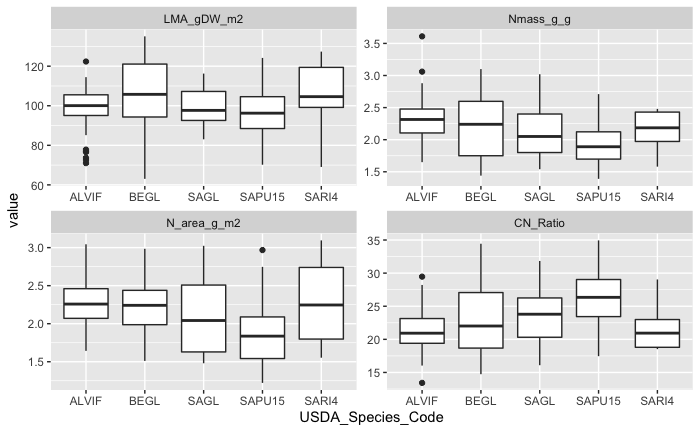

```r
# Graph the trait data and save a file to the scratch space
p2 <- ggplot(trait_data, aes(x=USDA_Species_Code, y=value)) +
  geom_boxplot() +
  facet_wrap(~variable, scale="free")
p2 # plot the results

# save the results to a file in the scratch space
ggsave(filename = file.path(outdir,"NGEE-Arctic_2016_Kougarok_Trait_data.png"), plot = p2,
       width = 40, height = 20, units = "cm")
```

# Disclaimer

*This vignette provided for demonstration purposes only*